# Risk Factor Analysis

## Outcome Variable

**Outcome Variable:** ever_stunted

## Predictor Variables

**Intervention Variable:** nhh

**Adjustment Set:**

unadjusted

## Stratifying Variables

The analysis was stratified on these variable(s):

- agecat
- studyid
- country

## Data Summary

| agecat | studyid | country | nhh | ever_stunted | n_cell | n |
| --- | --- | --- | --- | --- | --- | --- |
| 0-6 months | ki1000108-IRC | INDIA | 3 or less | 0 | 54 | 410 |
| 0-6 months | ki1000108-IRC | INDIA | 3 or less | 1 | 4 | 410 |
| 0-6 months | ki1000108-IRC | INDIA | 4-5 | 0 | 135 | 410 |
| 0-6 months | ki1000108-IRC | INDIA | 4-5 | 1 | 23 | 410 |
| 0-6 months | ki1000108-IRC | INDIA | 6-7 | 0 | 92 | 410 |
| 0-6 months | ki1000108-IRC | INDIA | 6-7 | 1 | 15 | 410 |
| 0-6 months | ki1000108-IRC | INDIA | 8+ | 0 | 79 | 410 |
| 0-6 months | ki1000108-IRC | INDIA | 8+ | 1 | 8 | 410 |
| 0-6 months | ki1000304b-SAS-FoodSuppl | INDIA | 3 or less | 0 | 26 | 416 |
| 0-6 months | ki1000304b-SAS-FoodSuppl | INDIA | 3 or less | 1 | 12 | 416 |
| 0-6 months | ki1000304b-SAS-FoodSuppl | INDIA | 4-5 | 0 | 110 | 416 |
| 0-6 months | ki1000304b-SAS-FoodSuppl | INDIA | 4-5 | 1 | 72 | 416 |
| 0-6 months | ki1000304b-SAS-FoodSuppl | INDIA | 6-7 | 0 | 79 | 416 |
| 0-6 months | ki1000304b-SAS-FoodSuppl | INDIA | 6-7 | 1 | 47 | 416 |
| 0-6 months | ki1000304b-SAS-FoodSuppl | INDIA | 8+ | 0 | 42 | 416 |
| 0-6 months | ki1000304b-SAS-FoodSuppl | INDIA | 8+ | 1 | 28 | 416 |
| 0-6 months | ki1017093-NIH-Birth | BANGLADESH | 3 or less | 0 | 98 | 629 |
| 0-6 months | ki1017093-NIH-Birth | BANGLADESH | 3 or less | 1 | 19 | 629 |
| 0-6 months | ki1017093-NIH-Birth | BANGLADESH | 4-5 | 0 | 221 | 629 |
| 0-6 months | ki1017093-NIH-Birth | BANGLADESH | 4-5 | 1 | 43 | 629 |
| 0-6 months | ki1017093-NIH-Birth | BANGLADESH | 6-7 | 0 | 122 | 629 |
| 0-6 months | ki1017093-NIH-Birth | BANGLADESH | 6-7 | 1 | 20 | 629 |
| 0-6 months | ki1017093-NIH-Birth | BANGLADESH | 8+ | 0 | 89 | 629 |
| 0-6 months | ki1017093-NIH-Birth | BANGLADESH | 8+ | 1 | 17 | 629 |
| 0-6 months | ki1017093b-PROVIDE | BANGLADESH | 3 or less | 0 | 131 | 700 |
| 0-6 months | ki1017093b-PROVIDE | BANGLADESH | 3 or less | 1 | 9 | 700 |
| 0-6 months | ki1017093b-PROVIDE | BANGLADESH | 4-5 | 0 | 286 | 700 |
| 0-6 months | ki1017093b-PROVIDE | BANGLADESH | 4-5 | 1 | 36 | 700 |
| 0-6 months | ki1017093b-PROVIDE | BANGLADESH | 6-7 | 0 | 137 | 700 |
| 0-6 months | ki1017093b-PROVIDE | BANGLADESH | 6-7 | 1 | 14 | 700 |

[output cut: 114 more lines]

The following strata were considered:

- agecat: 0-24 months, studyid: ki1000108-IRC, country: INDIA
- agecat: 0-24 months, studyid: ki1000304b-SAS-FoodSuppl, country: INDIA
- agecat: 0-24 months, studyid: ki1017093-NIH-Birth, country: BANGLADESH
- agecat: 0-24 months, studyid: ki1017093b-PROVIDE, country: BANGLADESH
- agecat: 0-24 months, studyid: ki1017093c-NIH-Crypto, country: BANGLADESH
- agecat: 0-24 months, studyid: ki1148112-LCNI-5, country: MALAWI
- agecat: 0-6 months, studyid: ki1000108-IRC, country: INDIA
- agecat: 0-6 months, studyid: ki1000304b-SAS-FoodSuppl, country: INDIA
- agecat: 0-6 months, studyid: ki1017093-NIH-Birth, country: BANGLADESH
- agecat: 0-6 months, studyid: ki1017093b-PROVIDE, country: BANGLADESH
- agecat: 0-6 months, studyid: ki1017093c-NIH-Crypto, country: BANGLADESH
- agecat: 0-6 months, studyid: ki1148112-LCNI-5, country: MALAWI
- agecat: 6-24 months, studyid: ki1000108-IRC, country: INDIA
- agecat: 6-24 months, studyid: ki1000304b-SAS-FoodSuppl, country: INDIA
- agecat: 6-24 months, studyid: ki1017093-NIH-Birth, country: BANGLADESH
- agecat: 6-24 months, studyid: ki1017093b-PROVIDE, country: BANGLADESH
- agecat: 6-24 months, studyid: ki1017093c-NIH-Crypto, country: BANGLADESH
- agecat: 6-24 months, studyid: ki1148112-LCNI-5, country: MALAWI

### Dropped Strata

Some strata were dropped due to rare outcomes:

- agecat: 0-6 months, studyid: ki1000108-IRC, country: INDIA
- agecat: 0-6 months, studyid: ki1148112-LCNI-5, country: MALAWI

## Methods Detail

We’re interested in the causal parameters $E[Y_a]$ for all values of $a \in \mathcal{A}$. These parameters represent the mean outcome if, possibly contrary to fact, we intervened to set all units to have $A=a$. Under the randomization and positivity assumptions, these are identified by the statistical parameters $\psi_a=E_W[E_{Y|A,W}(Y|A=a,W)]$. In addition, we’re interested in the mean of $Y$, $E[Y]$ under no intervention (the observed mean). We will estimate these parameters by using SuperLearner to fit the relevant likelihood factors – $E_{Y|A,W}(Y|A=a,W)$ and $p(A=a|W)$, and then updating our likelihood fit using a joint TMLE.

For unadjusted analyses ($W=\{\}$), initial likelihoods were estimated using Lrnr_glm to estimate the simple $E(Y|A)$ and Lrnr_mean to estimate $p(A)$. For adjusted analyses, a small library containing Lrnr_glmnet, Lrnr_xgboost, and Lrnr_mean was used.

Having estimated these parameters, we will then use the delta method to estimate relative risks and attributable risks relative to a prespecified baseline level of $A$.

# Results Detail

## Results Plots

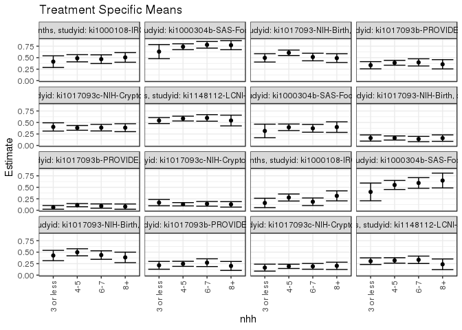

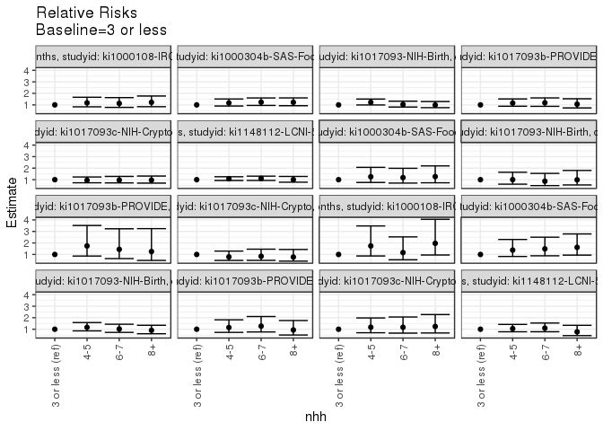

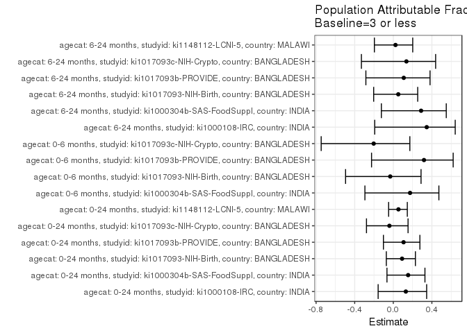

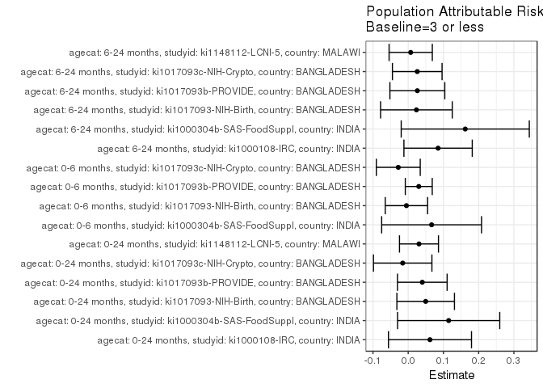

## Results Table

### Parameter: TSM

| agecat | studyid | country | intervention_level | baseline_level | estimate | ci_lower | ci_upper |
| --- | --- | --- | --- | --- | --- | --- | --- |
| 0-24 months | ki1000108-IRC | INDIA | 3 or less | NA | 0.4137931 | 0.2868873 | 0.5406989 |
| 0-24 months | ki1000108-IRC | INDIA | 4-5 | NA | 0.4873418 | 0.4093084 | 0.5653752 |
| 0-24 months | ki1000108-IRC | INDIA | 6-7 | NA | 0.4672897 | 0.3726387 | 0.5619407 |
| 0-24 months | ki1000108-IRC | INDIA | 8+ | NA | 0.5057471 | 0.4005606 | 0.6109336 |
| 0-24 months | ki1000304b-SAS-FoodSuppl | INDIA | 3 or less | NA | 0.6315789 | 0.4780245 | 0.7851334 |
| 0-24 months | ki1000304b-SAS-FoodSuppl | INDIA | 4-5 | NA | 0.7377049 | 0.6738963 | 0.8015135 |
| 0-24 months | ki1000304b-SAS-FoodSuppl | INDIA | 6-7 | NA | 0.7795276 | 0.7073405 | 0.8517146 |
| 0-24 months | ki1000304b-SAS-FoodSuppl | INDIA | 8+ | NA | 0.7714286 | 0.6729418 | 0.8699154 |
| 0-24 months | ki1017093-NIH-Birth | BANGLADESH | 3 or less | NA | 0.4957265 | 0.4050583 | 0.5863947 |
| 0-24 months | ki1017093-NIH-Birth | BANGLADESH | 4-5 | NA | 0.6060606 | 0.5470725 | 0.6650487 |
| 0-24 months | ki1017093-NIH-Birth | BANGLADESH | 6-7 | NA | 0.5140845 | 0.4318135 | 0.5963556 |
| 0-24 months | ki1017093-NIH-Birth | BANGLADESH | 8+ | NA | 0.4905660 | 0.3953230 | 0.5858091 |
| 0-24 months | ki1017093b-PROVIDE | BANGLADESH | 3 or less | NA | 0.3357143 | 0.2574332 | 0.4139954 |
| 0-24 months | ki1017093b-PROVIDE | BANGLADESH | 4-5 | NA | 0.3881988 | 0.3349312 | 0.4414663 |
| 0-24 months | ki1017093b-PROVIDE | BANGLADESH | 6-7 | NA | 0.3973510 | 0.3192441 | 0.4754579 |
| 0-24 months | ki1017093b-PROVIDE | BANGLADESH | 8+ | NA | 0.3563218 | 0.2556160 | 0.4570276 |
| 0-24 months | ki1017093c-NIH-Crypto | BANGLADESH | 3 or less | NA | 0.4035088 | 0.3133909 | 0.4936266 |
| 0-24 months | ki1017093c-NIH-Crypto | BANGLADESH | 4-5 | NA | 0.3830409 | 0.3314857 | 0.4345961 |
| 0-24 months | ki1017093c-NIH-Crypto | BANGLADESH | 6-7 | NA | 0.3876404 | 0.3160191 | 0.4592618 |
| 0-24 months | ki1017093c-NIH-Crypto | BANGLADESH | 8+ | NA | 0.3870968 | 0.3013082 | 0.4728854 |
| 0-24 months | ki1148112-LCNI-5 | MALAWI | 3 or less | NA | 0.5422222 | 0.4770836 | 0.6073609 |
| 0-24 months | ki1148112-LCNI-5 | MALAWI | 4-5 | NA | 0.5852941 | 0.5328941 | 0.6376942 |
| 0-24 months | ki1148112-LCNI-5 | MALAWI | 6-7 | NA | 0.5989011 | 0.5276516 | 0.6701506 |
| 0-24 months | ki1148112-LCNI-5 | MALAWI | 8+ | NA | 0.5428571 | 0.4260865 | 0.6596278 |
| 0-6 months | ki1000304b-SAS-FoodSuppl | INDIA | 3 or less | NA | 0.3157895 | 0.1678198 | 0.4637591 |
| 0-6 months | ki1000304b-SAS-FoodSuppl | INDIA | 4-5 | NA | 0.3956044 | 0.3244788 | 0.4667300 |
| 0-6 months | ki1000304b-SAS-FoodSuppl | INDIA | 6-7 | NA | 0.3730159 | 0.2884729 | 0.4575588 |
| 0-6 months | ki1000304b-SAS-FoodSuppl | INDIA | 8+ | NA | 0.4000000 | 0.2850981 | 0.5149019 |
| 0-6 months | ki1017093-NIH-Birth | BANGLADESH | 3 or less | NA | 0.1623932 | 0.0955119 | 0.2292745 |
| 0-6 months | ki1017093-NIH-Birth | BANGLADESH | 4-5 | NA | 0.1628788 | 0.1183010 | 0.2074565 |
| 0-6 months | ki1017093-NIH-Birth | BANGLADESH | 6-7 | NA | 0.1408451 | 0.0835845 | 0.1981057 |
| 0-6 months | ki1017093-NIH-Birth | BANGLADESH | 8+ | NA | 0.1603774 | 0.0904650 | 0.2302898 |
| 0-6 months | ki1017093b-PROVIDE | BANGLADESH | 3 or less | NA | 0.0642857 | 0.0236298 | 0.1049416 |
| 0-6 months | ki1017093b-PROVIDE | BANGLADESH | 4-5 | NA | 0.1118012 | 0.0773576 | 0.1462449 |
| 0-6 months | ki1017093b-PROVIDE | BANGLADESH | 6-7 | NA | 0.0927152 | 0.0464220 | 0.1390085 |
| 0-6 months | ki1017093b-PROVIDE | BANGLADESH | 8+ | NA | 0.0804598 | 0.0232627 | 0.1376568 |
| 0-6 months | ki1017093c-NIH-Crypto | BANGLADESH | 3 or less | NA | 0.1666667 | 0.0982099 | 0.2351234 |
| 0-6 months | ki1017093c-NIH-Crypto | BANGLADESH | 4-5 | NA | 0.1315789 | 0.0957297 | 0.1674282 |
| 0-6 months | ki1017093c-NIH-Crypto | BANGLADESH | 6-7 | NA | 0.1404494 | 0.0893730 | 0.1915259 |
| 0-6 months | ki1017093c-NIH-Crypto | BANGLADESH | 8+ | NA | 0.1290323 | 0.0699885 | 0.1880760 |
| 6-24 months | ki1000108-IRC | INDIA | 3 or less | NA | 0.1600000 | 0.0582336 | 0.2617664 |
| 6-24 months | ki1000108-IRC | INDIA | 4-5 | NA | 0.2781955 | 0.2019264 | 0.3544646 |
| 6-24 months | ki1000108-IRC | INDIA | 6-7 | NA | 0.1860465 | 0.1036800 | 0.2684131 |
| 6-24 months | ki1000108-IRC | INDIA | 8+ | NA | 0.3142857 | 0.2053740 | 0.4231974 |
| 6-24 months | ki1000304b-SAS-FoodSuppl | INDIA | 3 or less | NA | 0.4000000 | 0.2075373 | 0.5924627 |
| 6-24 months | ki1000304b-SAS-FoodSuppl | INDIA | 4-5 | NA | 0.5510204 | 0.4523254 | 0.6497154 |
| 6-24 months | ki1000304b-SAS-FoodSuppl | INDIA | 6-7 | NA | 0.5942029 | 0.4780825 | 0.7103233 |
| 6-24 months | ki1000304b-SAS-FoodSuppl | INDIA | 8+ | NA | 0.6470588 | 0.4860704 | 0.8080472 |
| 6-24 months | ki1017093-NIH-Birth | BANGLADESH | 3 or less | NA | 0.4266667 | 0.3145983 | 0.5387350 |
| 6-24 months | ki1017093-NIH-Birth | BANGLADESH | 4-5 | NA | 0.4969697 | 0.4205886 | 0.5733508 |
| 6-24 months | ki1017093-NIH-Birth | BANGLADESH | 6-7 | NA | 0.4363636 | 0.3435753 | 0.5291519 |
| 6-24 months | ki1017093-NIH-Birth | BANGLADESH | 8+ | NA | 0.3857143 | 0.2715488 | 0.4998798 |
| 6-24 months | ki1017093b-PROVIDE | BANGLADESH | 3 or less | NA | 0.2134831 | 0.1282661 | 0.2987001 |
| 6-24 months | ki1017093b-PROVIDE | BANGLADESH | 4-5 | NA | 0.2457627 | 0.1907781 | 0.3007474 |
| 6-24 months | ki1017093b-PROVIDE | BANGLADESH | 6-7 | NA | 0.2710280 | 0.1867225 | 0.3553336 |
| 6-24 months | ki1017093b-PROVIDE | BANGLADESH | 8+ | NA | 0.2000000 | 0.1026606 | 0.2973394 |
| 6-24 months | ki1017093c-NIH-Crypto | BANGLADESH | 3 or less | NA | 0.1630435 | 0.0874981 | 0.2385888 |
| 6-24 months | ki1017093c-NIH-Crypto | BANGLADESH | 4-5 | NA | 0.1913357 | 0.1449760 | 0.2376955 |
| 6-24 months | ki1017093c-NIH-Crypto | BANGLADESH | 6-7 | NA | 0.1907895 | 0.1282744 | 0.2533046 |
| 6-24 months | ki1017093c-NIH-Crypto | BANGLADESH | 8+ | NA | 0.2020202 | 0.1228659 | 0.2811745 |
| 6-24 months | ki1148112-LCNI-5 | MALAWI | 3 or less | NA | 0.3037975 | 0.2320255 | 0.3755694 |
| 6-24 months | ki1148112-LCNI-5 | MALAWI | 4-5 | NA | 0.3193277 | 0.2600458 | 0.3786097 |
| 6-24 months | ki1148112-LCNI-5 | MALAWI | 6-7 | NA | 0.3333333 | 0.2528455 | 0.4138212 |
| 6-24 months | ki1148112-LCNI-5 | MALAWI | 8+ | NA | 0.2352941 | 0.1187766 | 0.3518116 |

### Parameter: E(Y)

| agecat | studyid | country | intervention_level | baseline_level | estimate | ci_lower | ci_upper |
| --- | --- | --- | --- | --- | --- | --- | --- |
| 0-24 months | ki1000108-IRC | INDIA | NA | NA | 0.4756098 | 0.4272105 | 0.5240091 |
| 0-24 months | ki1000304b-SAS-FoodSuppl | INDIA | NA | NA | 0.7464115 | 0.7046540 | 0.7881689 |
| 0-24 months | ki1017093-NIH-Birth | BANGLADESH | NA | NA | 0.5453100 | 0.5063654 | 0.5842547 |
| 0-24 months | ki1017093b-PROVIDE | BANGLADESH | NA | NA | 0.3757143 | 0.3398113 | 0.4116172 |
| 0-24 months | ki1017093c-NIH-Crypto | BANGLADESH | NA | NA | 0.3878628 | 0.3531521 | 0.4225735 |
| 0-24 months | ki1148112-LCNI-5 | MALAWI | NA | NA | 0.5728274 | 0.5388870 | 0.6067678 |
| 0-6 months | ki1000304b-SAS-FoodSuppl | INDIA | NA | NA | 0.3822115 | 0.3354600 | 0.4289631 |
| 0-6 months | ki1017093-NIH-Birth | BANGLADESH | NA | NA | 0.1573927 | 0.1289105 | 0.1858749 |
| 0-6 months | ki1017093b-PROVIDE | BANGLADESH | NA | NA | 0.0942857 | 0.0726222 | 0.1159492 |
| 0-6 months | ki1017093c-NIH-Crypto | BANGLADESH | NA | NA | 0.1385224 | 0.1139141 | 0.1631308 |
| 6-24 months | ki1000108-IRC | INDIA | NA | NA | 0.2448378 | 0.1989973 | 0.2906782 |
| 6-24 months | ki1000304b-SAS-FoodSuppl | INDIA | NA | NA | 0.5619469 | 0.4971181 | 0.6267757 |
| 6-24 months | ki1017093-NIH-Birth | BANGLADESH | NA | NA | 0.4500000 | 0.4023647 | 0.4976353 |
| 6-24 months | ki1017093b-PROVIDE | BANGLADESH | NA | NA | 0.2394366 | 0.2018814 | 0.2769918 |
| 6-24 months | ki1017093c-NIH-Crypto | BANGLADESH | NA | NA | 0.1887097 | 0.1578857 | 0.2195336 |
| 6-24 months | ki1148112-LCNI-5 | MALAWI | NA | NA | 0.3108808 | 0.2731472 | 0.3486144 |

### Parameter: RR

| agecat | studyid | country | intervention_level | baseline_level | estimate | ci_lower | ci_upper |
| --- | --- | --- | --- | --- | --- | --- | --- |
| 0-24 months | ki1000108-IRC | INDIA | 3 or less | 3 or less | 1.0000000 | 1.0000000 | 1.000000 |
| 0-24 months | ki1000108-IRC | INDIA | 4-5 | 3 or less | 1.1777426 | 0.8332908 | 1.664578 |
| 0-24 months | ki1000108-IRC | INDIA | 6-7 | 3 or less | 1.1292835 | 0.7819558 | 1.630886 |
| 0-24 months | ki1000108-IRC | INDIA | 8+ | 3 or less | 1.2222222 | 0.8437581 | 1.770445 |
| 0-24 months | ki1000304b-SAS-FoodSuppl | INDIA | 3 or less | 3 or less | 1.0000000 | 1.0000000 | 1.000000 |
| 0-24 months | ki1000304b-SAS-FoodSuppl | INDIA | 4-5 | 3 or less | 1.1680328 | 0.9023663 | 1.511914 |
| 0-24 months | ki1000304b-SAS-FoodSuppl | INDIA | 6-7 | 3 or less | 1.2342520 | 0.9515135 | 1.601005 |
| 0-24 months | ki1000304b-SAS-FoodSuppl | INDIA | 8+ | 3 or less | 1.2214286 | 0.9281256 | 1.607420 |
| 0-24 months | ki1017093-NIH-Birth | BANGLADESH | 3 or less | 3 or less | 1.0000000 | 1.0000000 | 1.000000 |
| 0-24 months | ki1017093-NIH-Birth | BANGLADESH | 4-5 | 3 or less | 1.2225705 | 0.9937904 | 1.504018 |
| 0-24 months | ki1017093-NIH-Birth | BANGLADESH | 6-7 | 3 or less | 1.0370325 | 0.8132914 | 1.322326 |
| 0-24 months | ki1017093-NIH-Birth | BANGLADESH | 8+ | 3 or less | 0.9895901 | 0.7579052 | 1.292099 |
| 0-24 months | ki1017093b-PROVIDE | BANGLADESH | 3 or less | 3 or less | 1.0000000 | 1.0000000 | 1.000000 |
| 0-24 months | ki1017093b-PROVIDE | BANGLADESH | 4-5 | 3 or less | 1.1563367 | 0.8822333 | 1.515602 |
| 0-24 months | ki1017093b-PROVIDE | BANGLADESH | 6-7 | 3 or less | 1.1835987 | 0.8724780 | 1.605663 |
| 0-24 months | ki1017093b-PROVIDE | BANGLADESH | 8+ | 3 or less | 1.0613842 | 0.7357782 | 1.531081 |
| 0-24 months | ki1017093c-NIH-Crypto | BANGLADESH | 3 or less | 3 or less | 1.0000000 | 1.0000000 | 1.000000 |
| 0-24 months | ki1017093c-NIH-Crypto | BANGLADESH | 4-5 | 3 or less | 0.9492754 | 0.7313861 | 1.232077 |
| 0-24 months | ki1017093c-NIH-Crypto | BANGLADESH | 6-7 | 3 or less | 0.9606742 | 0.7189417 | 1.283685 |
| 0-24 months | ki1017093c-NIH-Crypto | BANGLADESH | 8+ | 3 or less | 0.9593268 | 0.7003624 | 1.314045 |
| 0-24 months | ki1148112-LCNI-5 | MALAWI | 3 or less | 3 or less | 1.0000000 | 1.0000000 | 1.000000 |
| 0-24 months | ki1148112-LCNI-5 | MALAWI | 4-5 | 3 or less | 1.0794359 | 0.9292430 | 1.253904 |
| 0-24 months | ki1148112-LCNI-5 | MALAWI | 6-7 | 3 or less | 1.1045307 | 0.9327197 | 1.307990 |
| 0-24 months | ki1148112-LCNI-5 | MALAWI | 8+ | 3 or less | 1.0011710 | 0.7825429 | 1.280880 |
| 0-6 months | ki1000304b-SAS-FoodSuppl | INDIA | 3 or less | 3 or less | 1.0000000 | 1.0000000 | 1.000000 |
| 0-6 months | ki1000304b-SAS-FoodSuppl | INDIA | 4-5 | 3 or less | 1.2527473 | 0.7584031 | 2.069316 |
| 0-6 months | ki1000304b-SAS-FoodSuppl | INDIA | 6-7 | 3 or less | 1.1812169 | 0.7019020 | 1.987847 |
| 0-6 months | ki1000304b-SAS-FoodSuppl | INDIA | 8+ | 3 or less | 1.2666667 | 0.7310865 | 2.194603 |
| 0-6 months | ki1017093-NIH-Birth | BANGLADESH | 3 or less | 3 or less | 1.0000000 | 1.0000000 | 1.000000 |
| 0-6 months | ki1017093-NIH-Birth | BANGLADESH | 4-5 | 3 or less | 1.0029904 | 0.6117040 | 1.644570 |
| 0-6 months | ki1017093-NIH-Birth | BANGLADESH | 6-7 | 3 or less | 0.8673091 | 0.4862332 | 1.547046 |
| 0-6 months | ki1017093-NIH-Birth | BANGLADESH | 8+ | 3 or less | 0.9875869 | 0.5421579 | 1.798974 |
| 0-6 months | ki1017093b-PROVIDE | BANGLADESH | 3 or less | 3 or less | 1.0000000 | 1.0000000 | 1.000000 |
| 0-6 months | ki1017093b-PROVIDE | BANGLADESH | 4-5 | 3 or less | 1.7391304 | 0.8606327 | 3.514362 |
| 0-6 months | ki1017093b-PROVIDE | BANGLADESH | 6-7 | 3 or less | 1.4422369 | 0.6443097 | 3.228335 |
| 0-6 months | ki1017093b-PROVIDE | BANGLADESH | 8+ | 3 or less | 1.2515964 | 0.4833293 | 3.241048 |
| 0-6 months | ki1017093c-NIH-Crypto | BANGLADESH | 3 or less | 3 or less | 1.0000000 | 1.0000000 | 1.000000 |
| 0-6 months | ki1017093c-NIH-Crypto | BANGLADESH | 4-5 | 3 or less | 0.7894737 | 0.4822575 | 1.292398 |
| 0-6 months | ki1017093c-NIH-Crypto | BANGLADESH | 6-7 | 3 or less | 0.8426966 | 0.4868760 | 1.458559 |
| 0-6 months | ki1017093c-NIH-Crypto | BANGLADESH | 8+ | 3 or less | 0.7741935 | 0.4186048 | 1.431841 |
| 6-24 months | ki1000108-IRC | INDIA | 3 or less | 3 or less | 1.0000000 | 1.0000000 | 1.000000 |
| 6-24 months | ki1000108-IRC | INDIA | 4-5 | 3 or less | 1.7387218 | 0.8698282 | 3.475575 |
| 6-24 months | ki1000108-IRC | INDIA | 6-7 | 3 or less | 1.1627907 | 0.5357288 | 2.523818 |
| 6-24 months | ki1000108-IRC | INDIA | 8+ | 3 or less | 1.9642857 | 0.9520022 | 4.052951 |
| 6-24 months | ki1000304b-SAS-FoodSuppl | INDIA | 3 or less | 3 or less | 1.0000000 | 1.0000000 | 1.000000 |
| 6-24 months | ki1000304b-SAS-FoodSuppl | INDIA | 4-5 | 3 or less | 1.3775510 | 0.8243944 | 2.301868 |
| 6-24 months | ki1000304b-SAS-FoodSuppl | INDIA | 6-7 | 3 or less | 1.4855072 | 0.8837582 | 2.496986 |
| 6-24 months | ki1000304b-SAS-FoodSuppl | INDIA | 8+ | 3 or less | 1.6176471 | 0.9411019 | 2.780551 |
| 6-24 months | ki1017093-NIH-Birth | BANGLADESH | 3 or less | 3 or less | 1.0000000 | 1.0000000 | 1.000000 |
| 6-24 months | ki1017093-NIH-Birth | BANGLADESH | 4-5 | 3 or less | 1.1647727 | 0.8591632 | 1.579090 |
| 6-24 months | ki1017093-NIH-Birth | BANGLADESH | 6-7 | 3 or less | 1.0227273 | 0.7294452 | 1.433927 |
| 6-24 months | ki1017093-NIH-Birth | BANGLADESH | 8+ | 3 or less | 0.9040179 | 0.6085782 | 1.342881 |
| 6-24 months | ki1017093b-PROVIDE | BANGLADESH | 3 or less | 3 or less | 1.0000000 | 1.0000000 | 1.000000 |
| 6-24 months | ki1017093b-PROVIDE | BANGLADESH | 4-5 | 3 or less | 1.1512043 | 0.7284844 | 1.819217 |
| 6-24 months | ki1017093b-PROVIDE | BANGLADESH | 6-7 | 3 or less | 1.2695524 | 0.7653696 | 2.105863 |
| 6-24 months | ki1017093b-PROVIDE | BANGLADESH | 8+ | 3 or less | 0.9368421 | 0.4992262 | 1.758067 |
| 6-24 months | ki1017093c-NIH-Crypto | BANGLADESH | 3 or less | 3 or less | 1.0000000 | 1.0000000 | 1.000000 |
| 6-24 months | ki1017093c-NIH-Crypto | BANGLADESH | 4-5 | 3 or less | 1.1735259 | 0.6956841 | 1.979581 |
| 6-24 months | ki1017093c-NIH-Crypto | BANGLADESH | 6-7 | 3 or less | 1.1701754 | 0.6634223 | 2.064010 |
| 6-24 months | ki1017093c-NIH-Crypto | BANGLADESH | 8+ | 3 or less | 1.2390572 | 0.6754005 | 2.273115 |
| 6-24 months | ki1148112-LCNI-5 | MALAWI | 3 or less | 3 or less | 1.0000000 | 1.0000000 | 1.000000 |
| 6-24 months | ki1148112-LCNI-5 | MALAWI | 4-5 | 3 or less | 1.0511204 | 0.7783285 | 1.419522 |
| 6-24 months | ki1148112-LCNI-5 | MALAWI | 6-7 | 3 or less | 1.0972222 | 0.7826792 | 1.538174 |
| 6-24 months | ki1148112-LCNI-5 | MALAWI | 8+ | 3 or less | 0.7745098 | 0.4474491 | 1.340634 |

### Parameter: PAR

| agecat | studyid | country | intervention_level | baseline_level | estimate | ci_lower | ci_upper |
| --- | --- | --- | --- | --- | --- | --- | --- |
| 0-24 months | ki1000108-IRC | INDIA | 3 or less | NA | 0.0618166 | -0.0560435 | 0.1796768 |
| 0-24 months | ki1000304b-SAS-FoodSuppl | INDIA | 3 or less | NA | 0.1148325 | -0.0302039 | 0.2598690 |
| 0-24 months | ki1017093-NIH-Birth | BANGLADESH | 3 or less | NA | 0.0495835 | -0.0321425 | 0.1313095 |
| 0-24 months | ki1017093b-PROVIDE | BANGLADESH | 3 or less | NA | 0.0400000 | -0.0304683 | 0.1104683 |
| 0-24 months | ki1017093c-NIH-Crypto | BANGLADESH | 3 or less | NA | -0.0156460 | -0.0986114 | 0.0673195 |
| 0-24 months | ki1148112-LCNI-5 | MALAWI | 3 or less | NA | 0.0306052 | -0.0246935 | 0.0859039 |
| 0-6 months | ki1000304b-SAS-FoodSuppl | INDIA | 3 or less | NA | 0.0664221 | -0.0752842 | 0.2081283 |
| 0-6 months | ki1017093-NIH-Birth | BANGLADESH | 3 or less | NA | -0.0050005 | -0.0651691 | 0.0551681 |
| 0-6 months | ki1017093b-PROVIDE | BANGLADESH | 3 or less | NA | 0.0300000 | -0.0082236 | 0.0682236 |
| 0-6 months | ki1017093c-NIH-Crypto | BANGLADESH | 3 or less | NA | -0.0281442 | -0.0904522 | 0.0341638 |
| 6-24 months | ki1000108-IRC | INDIA | 3 or less | NA | 0.0848378 | -0.0121301 | 0.1818056 |
| 6-24 months | ki1000304b-SAS-FoodSuppl | INDIA | 3 or less | NA | 0.1619469 | -0.0198485 | 0.3437423 |
| 6-24 months | ki1017093-NIH-Birth | BANGLADESH | 3 or less | NA | 0.0233333 | -0.0783670 | 0.1250337 |
| 6-24 months | ki1017093b-PROVIDE | BANGLADESH | 3 or less | NA | 0.0259535 | -0.0519662 | 0.1038732 |
| 6-24 months | ki1017093c-NIH-Crypto | BANGLADESH | 3 or less | NA | 0.0256662 | -0.0447859 | 0.0961183 |
| 6-24 months | ki1148112-LCNI-5 | MALAWI | 3 or less | NA | 0.0070834 | -0.0542654 | 0.0684321 |

### Parameter: PAF

| agecat | studyid | country | intervention_level | baseline_level | estimate | ci_lower | ci_upper |
| --- | --- | --- | --- | --- | --- | --- | --- |
| 0-24 months | ki1000108-IRC | INDIA | 3 or less | NA | 0.1299735 | -0.1570013 | 0.3457690 |
| 0-24 months | ki1000304b-SAS-FoodSuppl | INDIA | 3 or less | NA | 0.1538462 | -0.0655404 | 0.3280627 |
| 0-24 months | ki1017093-NIH-Birth | BANGLADESH | 3 or less | NA | 0.0909272 | -0.0722010 | 0.2292365 |
| 0-24 months | ki1017093b-PROVIDE | BANGLADESH | 3 or less | NA | 0.1064639 | -0.1022575 | 0.2756622 |
| 0-24 months | ki1017093c-NIH-Crypto | BANGLADESH | 3 or less | NA | -0.0403389 | -0.2778333 | 0.1530154 |
| 0-24 months | ki1148112-LCNI-5 | MALAWI | 3 or less | NA | 0.0534283 | -0.0482908 | 0.1452773 |
| 0-6 months | ki1000304b-SAS-FoodSuppl | INDIA | 3 or less | NA | 0.1737835 | -0.2941506 | 0.4725238 |
| 0-6 months | ki1017093-NIH-Birth | BANGLADESH | 3 or less | NA | -0.0317707 | -0.4944565 | 0.2876669 |
| 0-6 months | ki1017093b-PROVIDE | BANGLADESH | 3 or less | NA | 0.3181818 | -0.2253708 | 0.6206242 |
| 0-6 months | ki1017093c-NIH-Crypto | BANGLADESH | 3 or less | NA | -0.2031746 | -0.7473021 | 0.1715061 |
| 6-24 months | ki1000108-IRC | INDIA | 3 or less | NA | 0.3465060 | -0.1923464 | 0.6418370 |
| 6-24 months | ki1000304b-SAS-FoodSuppl | INDIA | 3 or less | NA | 0.2881890 | -0.1235849 | 0.5490551 |
| 6-24 months | ki1017093-NIH-Birth | BANGLADESH | 3 or less | NA | 0.0518519 | -0.2034044 | 0.2529652 |
| 6-24 months | ki1017093b-PROVIDE | BANGLADESH | 3 or less | NA | 0.1083939 | -0.2840804 | 0.3809099 |
| 6-24 months | ki1017093c-NIH-Crypto | BANGLADESH | 3 or less | NA | 0.1360089 | -0.3303679 | 0.4388916 |
| 6-24 months | ki1148112-LCNI-5 | MALAWI | 3 or less | NA | 0.0227848 | -0.1958878 | 0.2014723 |